# Practicing functions with Gapminder

Alexandra Pasternakova

created 13 October 2021, updated 13 October, 2021

## DESCRIPTION

Use the gapminder dataset from Week 05 to produce solutions to the three tasks below. Post the .R script or .Rmd and .html in your au##### github repository and link it here:

```r
head(gapminder)
```

```
## # A tibble: 6 x 6
##   country     continent  year lifeExp      pop gdpPercap
##   <fct>       <fct>     <int>   <dbl>    <int>     <dbl>
## 1 Afghanistan Asia       1952    28.8  8425333      779.
## 2 Afghanistan Asia       1957    30.3  9240934      821.
## 3 Afghanistan Asia       1962    32.0 10267083      853.
## 4 Afghanistan Asia       1967    34.0 11537966      836.
## 5 Afghanistan Asia       1972    36.1 13079460      740.
## 6 Afghanistan Asia       1977    38.4 14880372      786.
```

**Your Tasks:**

## 1) GDP

Define a defensive function that calculates the Gross Domestic Product of a nation from the data available in the gapminder dataset. You can use the population and GDPpercapita columns for it. Using that function, calculate the GDP of Denmark in the following years: 1967, 1977, 1987, 1997, 2007, and 2017.

```r
#we define the function calcGDP by assigning it to the output of function()
#we set year and country to NULL to ensure there is no prior value from some code we ran before, it will stay NULL until we specify otherwise
 #the function now subsets the provided data by year if the year argument isn’t empty, then subsets the result by  country if the country argument isn’t empty
calcGDP <- function(dat, year=NULL, country=NULL) {
  if(!is.null(year)) {
    dat <- dat[dat$year %in% year, ]
  }

  if (!is.null(country)) {
    dat <- dat[dat$country %in% country,]
  }

  gdp <- dat$pop * dat$gdpPercap #calculates GDP

  new <- cbind(dat, gdp=gdp) #adds GDP as a column
  return(new)
}

#calls the function, we specify data, years we are interested in and the country name
calcGDP(gapminder, year=c(1967, 1977,1987,1997,2007,2017), country="Denmark")
```

```
##   country continent year lifeExp     pop gdpPercap          gdp
## 1 Denmark    Europe 1967  72.960 4838800  15937.21  77116977700
## 2 Denmark    Europe 1977  74.690 5088419  20422.90 103920280028
## 3 Denmark    Europe 1987  74.800 5127024  25116.18 128771236166
## 4 Denmark    Europe 1997  76.110 5283663  29804.35 157476118456
## 5 Denmark    Europe 2007  78.332 5468120  35278.42 192906627081
```

```r
#we only see 5 rows = 5 years, because the gapminder data doesn't include year 2017 as we can see here
unique(gapminder$year)
```

```
##  [1] 1952 1957 1962 1967 1972 1977 1982 1987 1992 1997 2002 2007
```

```r
#I tried many times to somehow make it type back a message signifying that some data (2017) is missing but can`t seem to make it work properly
#if we only use the function on the missing year it will return nothing because the values are NULL so it does serve the purpose of not creating "wrong" data
calcGDP(gapminder, year=2017, country="Denmark")
```

```
## [1] country   continent year      lifeExp   pop       gdpPercap gdp
## <0 rows> (or 0-length row.names)
```

## 2) Loop

Write a script that loops over each country in the gapminder dataset, tests whether the country starts with a ‘B’ , and prints out whether the life expectancy is smaller than 50, between 50 and 70, or greater than 70. (Hint: remember the grepl functions, and review the Control Flow tutorial)

```r
#Firstly I define the lower and upper threshold so we can later define our conditions
lowerThreshold <- 50
upperThreshold <- 70
#I create a vector containing all names of countries starting with B using grep function
#grep searches for matches to argument pattern within each element of a character vector - in our case the starting letter B, we let the function to sift through all the country names using unique function
candidateCountries <- grep("^B", unique(gapminder$country), value = TRUE)
#we create loop with 3 different conditions, it is either "less than", "between" or "greater than", we specify what to print if the condition is met
for ( iCountry in candidateCountries) {
    tmp <- mean(subset(gapminder, country==iCountry)$lifeExp) #calculates the mean life expectancy for the country currently in the loop

    if(tmp < lowerThreshold) {
        cat("Average Life Expectancy in", iCountry, "is less than", lowerThreshold, "\n") #prints the text with the country currently in the loop, same logic follows
    }
    else if(tmp > lowerThreshold && tmp < upperThreshold) {
        cat("Average Life Expectancy in", iCountry, "is between", lowerThreshold, "and", upperThreshold, "\n")
    }
    else {
        cat("Average Life Expectancy in", iCountry, "is greater than", upperThreshold, "\n")
    }
    rm(tmp)
}
```

```
## Average Life Expectancy in Bahrain is between 50 and 70
## Average Life Expectancy in Bangladesh is less than 50
## Average Life Expectancy in Belgium is greater than 70
## Average Life Expectancy in Benin is less than 50
## Average Life Expectancy in Bolivia is between 50 and 70
## Average Life Expectancy in Bosnia and Herzegovina is between 50 and 70
## Average Life Expectancy in Botswana is between 50 and 70
## Average Life Expectancy in Brazil is between 50 and 70
## Average Life Expectancy in Bulgaria is between 50 and 70
## Average Life Expectancy in Burkina Faso is less than 50
## Average Life Expectancy in Burundi is less than 50
```

## 3) Challenge loop

Challenge/Optional: Write a script that loops over each country in the gapminder dataset, tests whether the country starts with a ‘M’ and graphs life expectancy against time (using plot() function) as a line graph if the mean life expectancy is under 50 years.

```
## Average Life Expectancy in Madagascar is less than 50 plotting life expectancy graph...
```

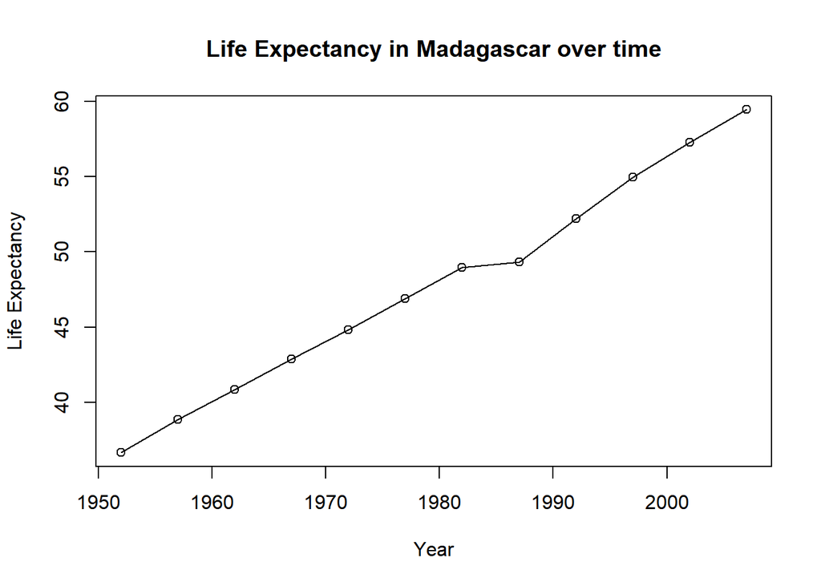

```
## Average Life Expectancy in Malawi is less than 50 plotting life expectancy graph...
```

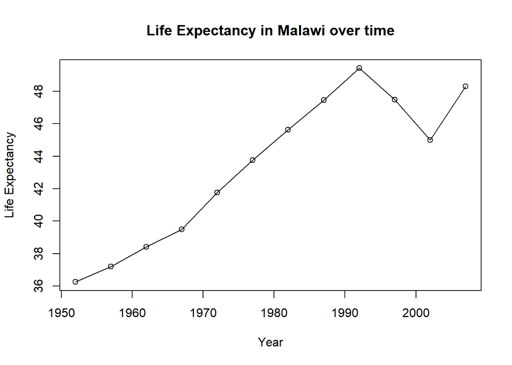

```
## Average Life Expectancy in Mali is less than 50 plotting life expectancy graph...
```

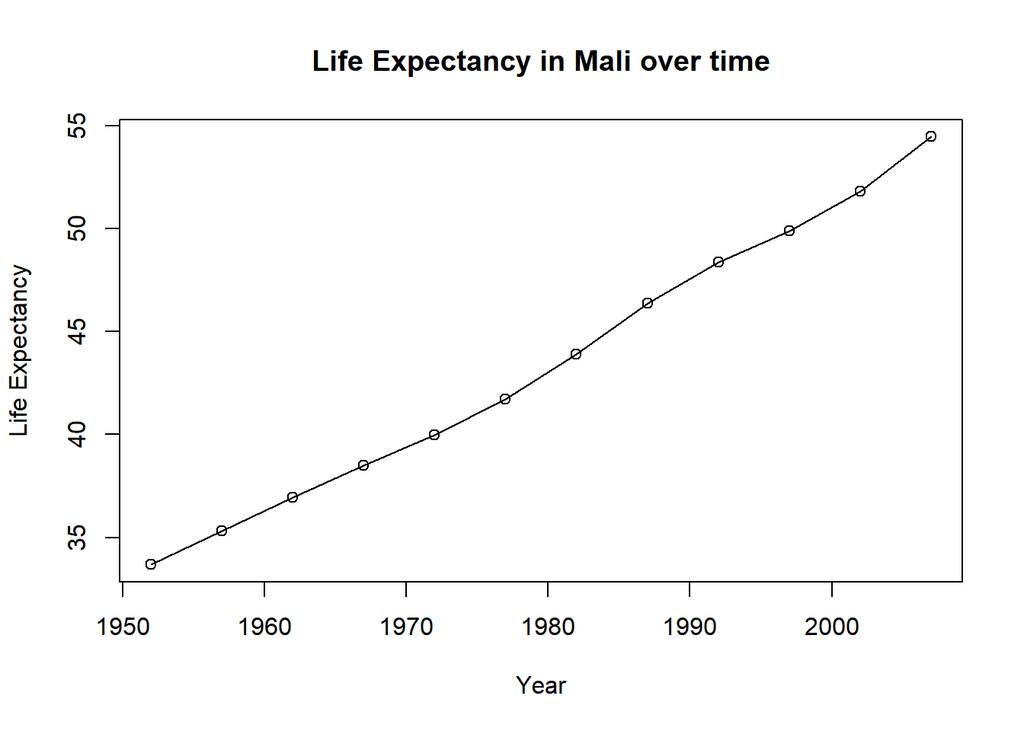

```
## Average Life Expectancy in Mozambique is less than 50 plotting life expectancy graph...
```

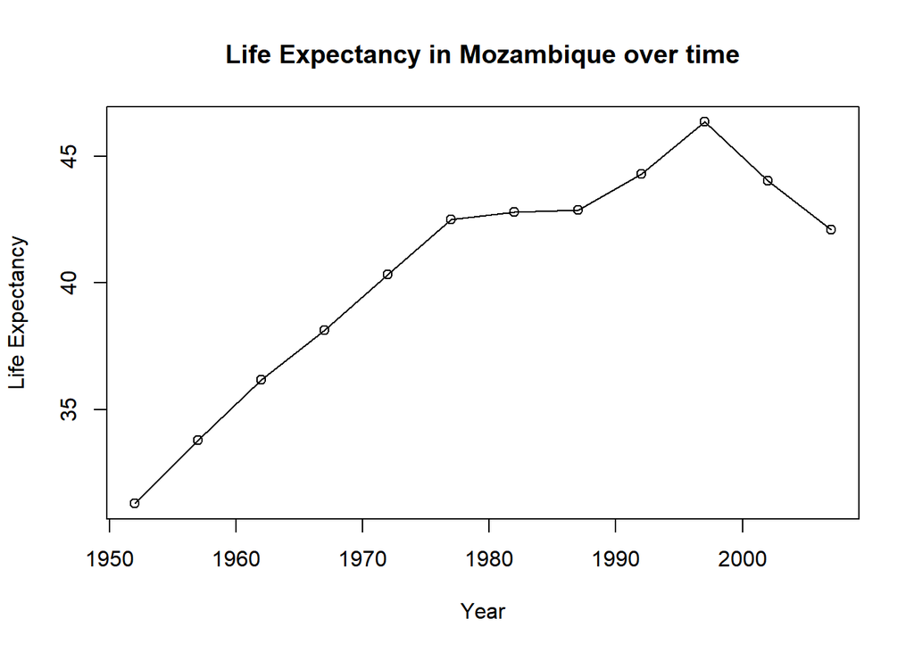

```r
thresholdValue <- 50 #defines our threshold
candidateCountries <- grep("^M", unique(gapminder$country), value = TRUE) #find all countries starting with M
#similar to previous loop, only if the mean life expectancy is smaller than threshold value, the program plots it against time
for (iCountry in candidateCountries) {
    tmp <- mean(subset(gapminder, country==iCountry)$lifeExp)

    if (tmp < thresholdValue) {
        cat("Average Life Expectancy in", iCountry, "is less than", thresholdValue, "plotting life expectancy graph... \n")

        with(subset(gapminder, country == iCountry),
                plot(year, lifeExp,
                     type = "o",
                     main = paste("Life Expectancy in", iCountry, "over time"),
                     ylab = "Life Expectancy",
                     xlab = "Year"
                     ) #end plot
             ) #end with
    } #end if
    rm(tmp)
} #end loop
```